# ps5-rmarkdown-plot

Minkyu Kim

2023-02-15

## 1. Load and Check data

1. Done

```r
library(tidyverse)
```

```r
gapminder <- read_delim("data/gapminder.csv.bz2")
```

The data set has **13055 rows** and **25 columns**.

```r
gapminder %>%
  sample_n(5)
```

```
## # A tibble: 5 × 25
##   iso3  name  iso2  region sub-r…¹ inter…²  time total…³ ferti…⁴ lifeE…⁵ child…⁶
##   <chr> <chr> <chr> <chr>  <chr>   <chr>   <dbl>   <dbl>   <dbl>   <dbl>   <dbl>
## 1 CMR   Came… CM    Africa Sub-Sa… Middle…  1983  9.46e6    6.70    52.7   160.
## 2 MMR   Myan… MM    Asia   South-… <NA>     1961  2.22e7    6.07    43.0    NA
## 3 HND   Hond… HN    Ameri… Latin … Centra…  2013  8.80e6    2.70    74.1    20.7
## 4 IRN   Iran… IR    Asia   Southe… <NA>     1970  2.85e7    6.44    50.9    NA
## 5 VGB   Virg… VG    Ameri… Latin … Caribb…  1998  1.98e4   NA       NA      NA
## # … with 14 more variables: youthFemaleLiteracy <dbl>, youthMaleLiteracy <dbl>,
## #   adultLiteracy <dbl>, GDP_PC <dbl>, accessElectricity <dbl>,
## #   agriculturalLand <dbl>, agricultureTractors <dbl>, cerealProduction <dbl>,
## #   fertilizerHa <dbl>, co2 <dbl>, greenhouseGases <dbl>, co2_PC <dbl>,
## #   pm2.5_35 <dbl>, battleDeaths <dbl>, and abbreviated variable names
## #   ¹`sub-region`, ²`intermediate-region`, ³totalPopulation, ⁴fertilityRate,
## #   ⁵lifeExpectancy, ⁶childMortality
```

It looks okay to me :)

## 2. Descriptive Statistics

```r
cntrycnt <- gapminder %>%
  summarize(nIso3 = n_distinct(iso3), nIso2 = n_distinct(iso2), nName = n_distinct(name))
```

The *iso3*, *iso2*, and *name* variables indicate that there are **253**, **249**, and **250 countries** respectively.

2a.

```r
iso2Count <- gapminder %>%
  group_by(iso2) %>%
  distinct(name) %>%
  filter((length(name) > 1)) %>%
  filter(!is.na(name))
```

There is normally only supposed to be one name to one *iso2 code*. The *iso2 code* associated with more than one *name* is **NA**. The country under the *iso2 code* **NA** is **Namibia**.

2b.

```r
nameCount <- gapminder %>%
  group_by(name) %>%
  distinct(iso3) %>%
  filter((length(iso3)) > 1) %>%
  filter(!is.na(iso3))
```

There is additionally only supposed to be one *iso3 code* to one *name*. The *name* associated with more than one *iso3 code* is **NA**. The countries under **NA** are **CHANISL, GBM, KOS, NLD_CURACAO**.

```r
times <- gapminder %>%
  filter(!is.na(time)) %>%
  distinct(time) %>%
  summarize(min = min(time), max = max(time))
```

The *minimum year* in the data is **1960** while the *maximum year* in the data is **2019.**

## 3. CO2 Emissions

```r
missingCo2Data <- gapminder %>%
  group_by(time) %>%
  mutate(missingCo2 = sum(is.na(co2)), missingCo2_PC = sum(is.na(co2_PC))) %>%
  reframe(totalMissingCo2 = (missingCo2 + missingCo2_PC)) %>%
  distinct(time, .keep_all = TRUE) %>%
  arrange(desc(totalMissingCo2)) %>%
  ungroup()

missingCo2Data
```

```
## # A tibble: 61 × 2
##     time totalMissingCo2
##    <dbl>           <int>
##  1  2017             434
##  2  2018             434
##  3  2019             434
##  4  1960             120
##  5  1961             120
##  6  1962             116
##  7  1963             114
##  8  1964             102
##  9  1965             102
## 10  1966             102
## # … with 51 more rows
```

```r
maxMissing <- missingCo2Data %>%
  filter(totalMissingCo2 == max(totalMissingCo2))
```

The years **2017, 2018, 2019** have the most missing data of **434**.

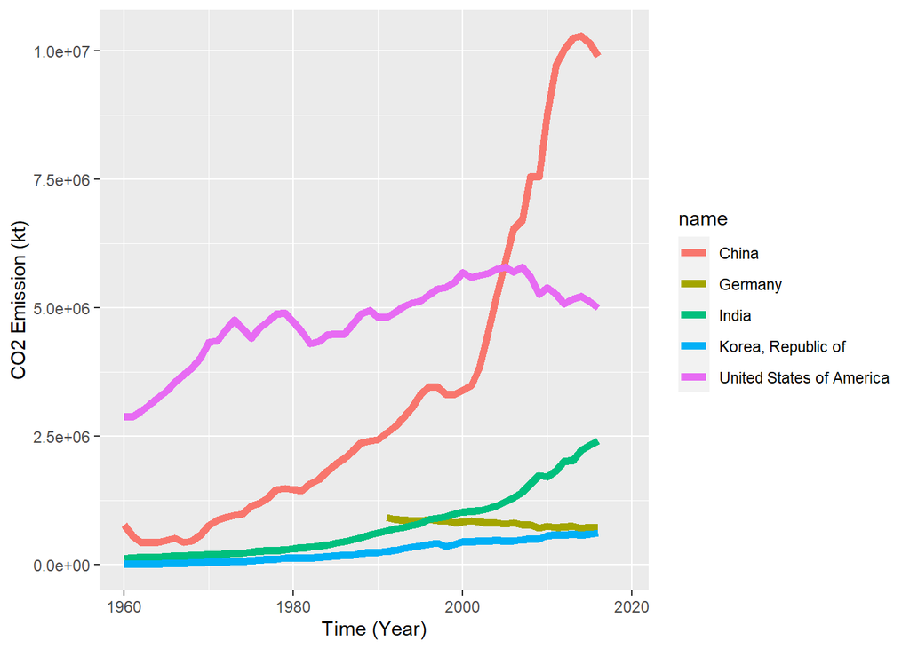

```r
totalEmission <- gapminder %>%
  filter(name %in% c("United States of America", "China", "India", "Germany", "Korea, Republic of"))

totalEmission %>%
  ggplot(aes(time, co2, col=name)) +
  geom_line(linewidth=2, na.rm=TRUE) +
  labs(x = "Time (Year)", y = "CO2 Emission (kt)")
```

I see that in terms of ranking CO2 emissions, the order from least to greatest is **South Korea**, **Germany**, **India**, the **United States**, and **China.**

**South Korea**, **India**, and **China** are all increasing while Germany and the United States are decreasing.

Additionally, no data is provided for **Germany** before *1990* because reunification between East and West Germany did not occur until *1989*, meaning that any data before that is unknown.

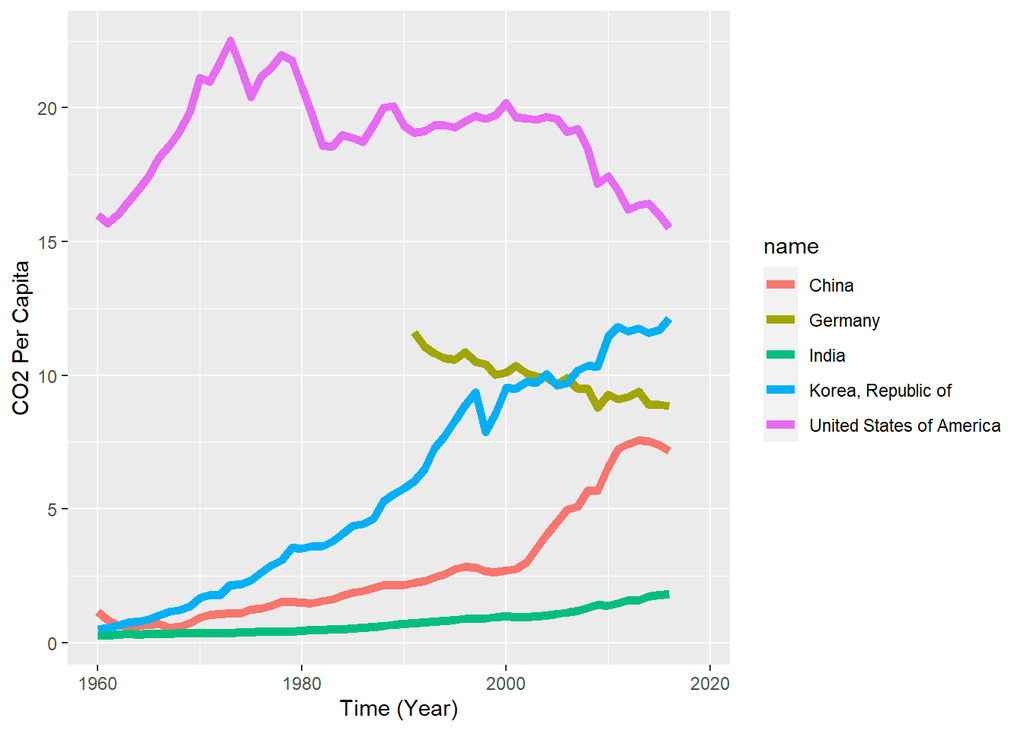

```r
totalEmission_PC <- gapminder %>%
  filter(name %in% c("United States of America", "China", "India", "Germany", "Korea, Republic of"))

totalEmission_PC %>%
  ggplot(aes(time, co2_PC, col=name)) +
  geom_line(linewidth=2, na.rm = TRUE) +
  labs(x = "Time (Year)", y = "CO2 Per Capita")
```

I notice that *Germany* and the **US’s** CO2 per Capita has been decreasing while those of **South Korea** and **China** have experienced a rapid increase in CO2 Emissions per Capita and **India’s** CO2 emissions per capital have been gradually increasing.

This figure suggests that **Germany** and the **US**, whose capita and overall development are greater than those of the other three, have been gradually decreasing the amount of CO2 they emit over time, implying that they are finding more effective ways of reducing CO2 emissions. Meanwhile **South Korea** and **China** are experiencing a massive growth in CO2 emissions per capita, suggesting that they only recently have experienced great industrialization and development and so CO2 emissions are increasing as consequence.

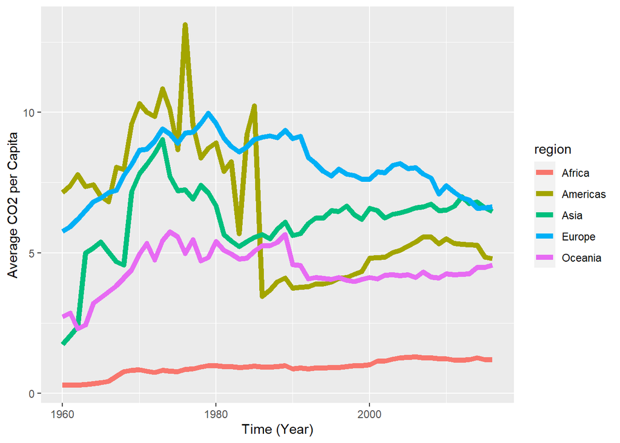

```r
regionalCo2PC <- gapminder %>%
  group_by(region, time) %>%
  filter(!is.na(co2_PC), !is.na(region)) %>%
  summarize(meanCo2_PC = mean(co2_PC), .groups = "keep")

regionalCo2PC %>%
  ggplot(aes(time, meanCo2_PC, col=region)) +
  geom_line(size=2) +
  labs(x = "Time (Year)", y = "Average CO2 per Capita")
```

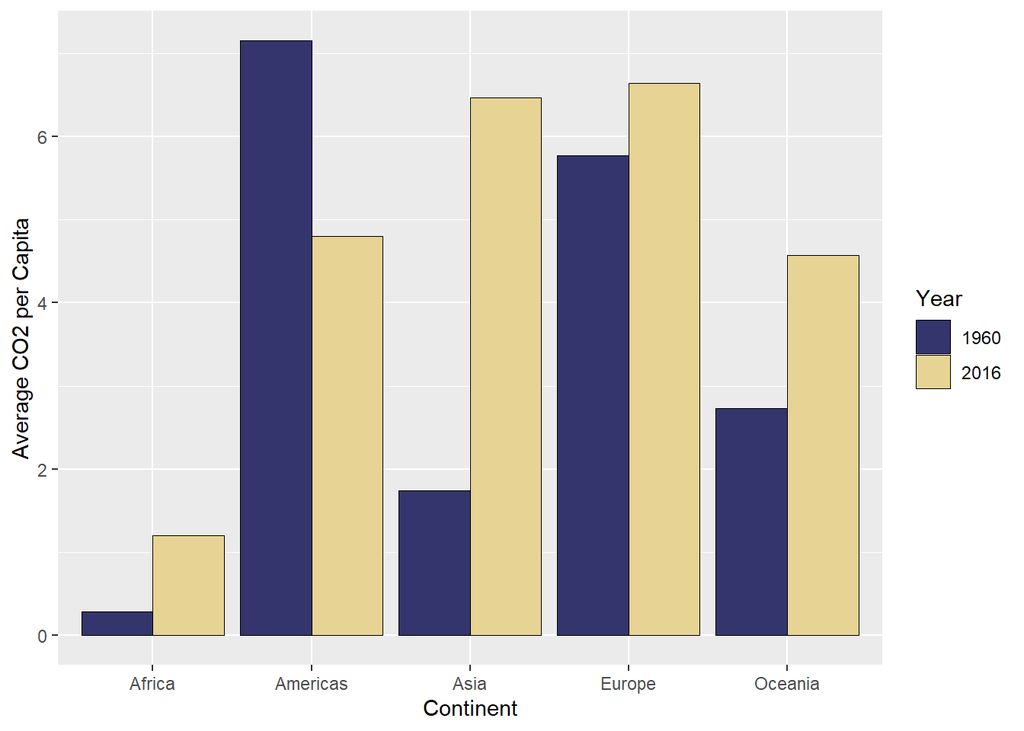

```r
regionalCo2PC %>%
  filter(time %in% c(1960, 2016)) %>%
  ggplot(aes(region, meanCo2_PC, fill=factor(time))) +
  geom_col(position = "dodge", col="black", size=0.2) +
  scale_fill_manual(values=(c("#34356d", "#e7d393"))) +
  labs(x = "Continent", y = "Average CO2 per Capita", fill = "Year")
```

```r
rankedRegionalCo2 <- gapminder %>%
  filter(time == 2016, !is.na(name)) %>%
  group_by(region) %>%
  select(time, name, region, co2_PC)

rankedRegionalCo2 %>%
  slice_max(co2_PC, n = 3)
```

```
## # A tibble: 15 × 4
## # Groups:   region [5]
##     time name                     region   co2_PC
##    <dbl> <chr>                    <chr>     <dbl>
##  1  2016 South Africa             Africa     8.48
##  2  2016 Libya                    Africa     7.79
##  3  2016 Seychelles               Africa     6.39
##  4  2016 Trinidad and Tobago      Americas  31.8
##  5  2016 United States of America Americas  15.5
##  6  2016 Canada                   Americas  15.1
##  7  2016 Qatar                    Asia      38.9
##  8  2016 Kuwait                   Asia      25.0
##  9  2016 Bahrain                  Asia      22.2
## 10  2016 Gibraltar                Europe    18.8
## 11  2016 Luxembourg               Europe    15.4
## 12  2016 Faroe Islands            Europe    13.1
## 13  2016 New Caledonia            Oceania   19.3
## 14  2016 Australia                Oceania   15.5
## 15  2016 Palau                    Oceania   12.6
```

```r
rankedRegionalCo2 %>%
  slice_min(co2_PC, n = 3)
```

```
## # A tibble: 15 × 4
## # Groups:   region [5]
##     time name                              region   co2_PC
##    <dbl> <chr>                             <chr>     <dbl>
##  1  2016 Congo, Democratic Republic of the Africa   0.0256
##  2  2016 Somalia                           Africa   0.0455
##  3  2016 Burundi                           Africa   0.0472
##  4  2016 Haiti                             Americas 0.275
##  5  2016 Nicaragua                         Americas 0.887
##  6  2016 Honduras                          Americas 1.06
##  7  2016 Afghanistan                       Asia     0.245
##  8  2016 Nepal                             Asia     0.334
##  9  2016 Yemen                             Asia     0.390
## 10  2016 Liechtenstein                     Europe   1.36
## 11  2016 Albania                           Europe   1.58
## 12  2016 Moldova, Republic of              Europe   1.83
## 13  2016 Solomon Islands                   Oceania  0.272
## 14  2016 Vanuatu                           Oceania  0.527
## 15  2016 Kiribati                          Oceania  0.587
```

Because a large portion of the data for CO2 emissions per capita for **2019** were missing, I decided to go with **2016** instead. The **top 3** and **bottom 3** CO2 emitters for each continent are provided in the data sets above.

## 4. GDP Per Capita

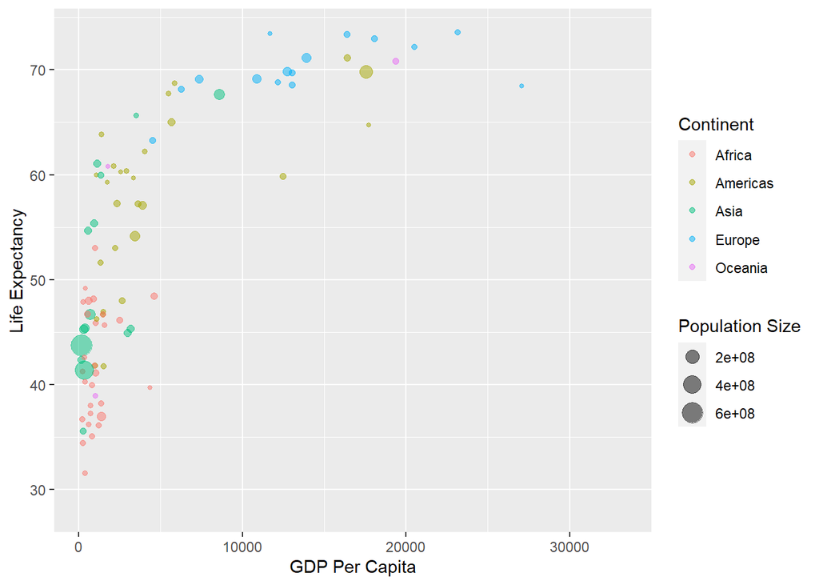

```r
gapminder %>%
  filter(time == 1960, !is.na(region)) %>%
  ggplot(aes(GDP_PC, lifeExpectancy, col=region, size=totalPopulation)) +
  geom_point(alpha = 0.5, na.rm = TRUE) +
  labs(x = "GDP Per Capita", y = "Life Expectancy", size = "Population Size", col = "Continent")
```

I decided to have the size of the points on the scatter plot be based on *population size* and not the *country size* because the only data that represents land size is the agriculturalLand variable, which is missing for some countries.

I notice that **Europe** consistently has the highest *life expectancy* but also has the most distributed *GDP per capita* compared to the other regions. **Africa** and **Asia** are consistently concentrated around the lower end in regards to *GDP per capita*. The **Americas** have several outliers with a high **GDP per capita** and *life expectancy* but also has countries that have both a lower *life expectancy* and **GDP per capita**. **Oceania** has the most scattered points in terms of *GDP per capita* and *life expectancy*

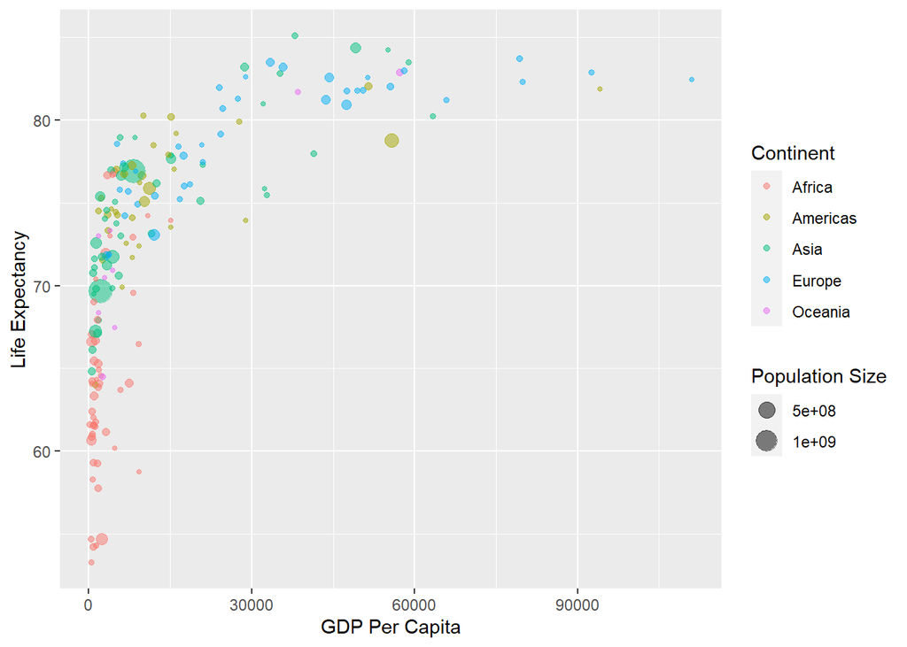

```r
gapminder %>%
  filter(time == 2019, !is.na(region)) %>%
  ggplot(aes(GDP_PC, lifeExpectancy, col=region, size=totalPopulation)) +
  geom_point(alpha = 0.5, na.rm = TRUE) +
  labs(x = "GDP Per Capita", y = "Life Expectancy", size = "Population Size", col = "Continent")
```

3. Overall, the *life expectancy* and *size* of each country has increased in the time between **1960** and **2019**, with many more countries being larger and higher up in terms of *life expectancy.*

```r
gapminder %>%
  group_by(region) %>%
  filter(time == 1960, !is.na(lifeExpectancy), !is.na(region)) %>%
  summarize(avgLE = mean(lifeExpectancy))
```

```
## # A tibble: 5 × 2
##   region   avgLE
##   <chr>    <dbl>
## 1 Africa    41.5
## 2 Americas  58.6
## 3 Asia      51.6
## 4 Europe    68.3
## 5 Oceania   56.4
```

```r
gapminder %>%
  group_by(region) %>%
  filter(time == 2019, !is.na(lifeExpectancy), !is.na(region)) %>%
  summarize(avgLE = mean(lifeExpectancy))
```

```
## # A tibble: 5 × 2
##   region   avgLE
##   <chr>    <dbl>
## 1 Africa    64.1
## 2 Americas  75.8
## 3 Asia      74.6
## 4 Europe    79.4
## 5 Oceania   73.5
```

The results seem to align with what I observed between the two scatter plots, that being that the *life expectancy* of each country having **increased** between 1960 and 2019. This correlates with the average life expectancy being larger overall in **2019** than in **1960.**

```r
gapminder %>%
  group_by(region) %>%
  filter(time %in% c(1960, 2019)) %>%
  mutate(le1960 = lag(lifeExpectancy)) %>%
  select(time, name, region, lifeExpectancy, le1960) %>%
  filter(time == 2019) %>%
  mutate(growth = lifeExpectancy - le1960) %>%
  filter(!is.na(growth), !is.na(name)) %>%
  summarize(avgGrowth = mean(growth))
```

```
## # A tibble: 5 × 2
##   region   avgGrowth
##   <chr>        <dbl>
## 1 Africa        22.5
## 2 Americas      16.9
## 3 Asia          22.4
## 4 Europe        11.0
## 5 Oceania       17.1
```

I see that overall, the *average growth rate* of each continent’s *life expectancy* has **increased.**

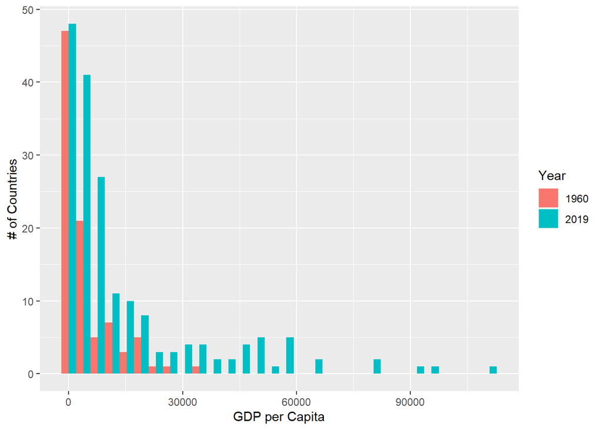

```r
gapminder %>%
  group_by(time) %>%
  filter(time %in% c(1960, 2019)) %>%
  ggplot(aes(GDP_PC, fill=factor(time))) +
  geom_histogram(position = "dodge", na.rm = TRUE) +
  labs(x = "GDP per Capita", y = "# of Countries", fill = "Year")
```

```r
usLe <- gapminder %>%
  group_by(time) %>%
  filter(time %in% c(1960, 2019), !is.na(name)) %>%
  mutate(rank = rank(desc(lifeExpectancy))) %>%
  select(name, time, lifeExpectancy, rank) %>%
  filter(name == "United States of America")
```

The ranking of the **US** in terms of *life expectancy* in *1960* was **17** and the ranking in **2019** was **46**

```r
gapminder %>%
  group_by(time) %>%
  filter(time %in% c(1960, 2019), !is.na(name), !is.na(lifeExpectancy)) %>%
  mutate(rank = rank(desc(lifeExpectancy))) %>%
  select(name, time, lifeExpectancy, rank) %>%
  summarize(time, name, rank, relativeRank = rank/n()) %>%
  arrange(rank)
```

```
## # A tibble: 384 × 4
## # Groups:   time [2]
##     time name         rank relativeRank
##    <dbl> <chr>       <dbl>        <dbl>
##  1  1960 Norway          1      0.00532
##  2  2019 Hong Kong       1      0.00510
##  3  1960 Iceland         2      0.0106
##  4  2019 Japan           2      0.0102
##  5  1960 Netherlands     3      0.0160
##  6  2019 Macao           3      0.0153
##  7  1960 Sweden          4      0.0213
##  8  2019 Switzerland     4      0.0204
##  9  1960 Denmark         5      0.0266
## 10  2019 Singapore       5      0.0255
## # … with 374 more rows
```

I spent roughly 5-8 hours on and off